```python
from IPython.display import HTML
HTML('''<script>
code_show=true;
function code_toggle() {
 if (code_show){
 $('div.input').hide();
 } else {
 $('div.input').show();
 }
 code_show = !code_show
}
$( document ).ready(code_toggle);
</script>
<form action="javascript:code_toggle()"><input type="submit" value="Click here to toggle on/off the raw code."></form>''')
```

## 🐍 [One Point Tutorial] Visualization II

# `seaborn`

빅데이터 분석 초급과정 with 관악구, KMR

2023 1st | All rights reserved by Wooseok Song

## 2. *seaborn* 을 배워 보자 !

- **seaborn이란?**  
  Matplotlib을 기반으로 다양한 색상 테마와 통계용 차트 등의 기능을 추가한 시각화 패키지

### 학습 목표

`seaborn`의 핵심적인 시각화 기법을 이해하고 활용함

### 목차

1. Scatter Plot
2. Box Plot
3. Violin Plot
4. Bar Plot
5. Rug plot
6. KDe Plot(Line Histogram)
7. Count Plot
8. Joint Plot
9. Pair Plot
10. Reg plot & LM Plot

### Import module (모듈 설치 후 불러오기)

seaborn 모듈이 설치 안 되어 있다면, 설치부터 하기!

```python
import numpy as np
import pandas as pd

# !pip install seaborn
import seaborn as sns

import os
```

```python
try:
    os.chdir("/Users/wooseoksong/Desktop/archive/")
    print("Directory changed")
except OSError:
    print("Can't change the Current Working Directory")
```

[output not shown]

### Import data

seaborn 패키지에는 데이터들이 내장되어 있다.  
불러와보자!

```python
iris = sns.load_dataset("iris")    # 붓꽃 데이터
titanic = sns.load_dataset("titanic")    # 타이타닉호 데이터
tips = sns.load_dataset("tips")    # 팁 데이터
flights = sns.load_dataset("flights")    # 여객운송 데이터
```

```python
tips.head()
```

|  | total_bill | tip | sex | smoker | day | time | size |
| --- | --- | --- | --- | --- | --- | --- | --- |
| 0 | 16.99 | 1.01 | Female | No | Sun | Dinner | 2 |
| 1 | 10.34 | 1.66 | Male | No | Sun | Dinner | 3 |
| 2 | 21.01 | 3.50 | Male | No | Sun | Dinner | 3 |
| 3 | 23.68 | 3.31 | Male | No | Sun | Dinner | 2 |
| 4 | 24.59 | 3.61 | Female | No | Sun | Dinner | 4 |

### 2.1. Scatter Plot

#### 2.1.1. 첫번째 그래프: 분석하고자 하는 데이터가 numerical 일 때 !

> **사용 방법 :**
> 1. sns.relplot(`x축 데이터`,`y축 데이터`,`data`)
> 2. sns.scatterplot(`data`,`x축 데이터`,`y축 데이터`)

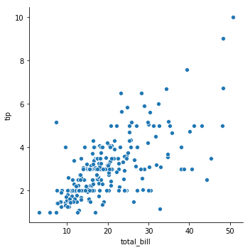

```python
sns.relplot(x="total_bill", y="tip", data=tips)
```

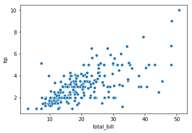

```python
sns.scatterplot(data=tips, x="total_bill", y="tip")
```

보이기에 따라서 조금 차이가 있지만 둘 다 scatter plot(산포도)을 그리고 있다.

- 카테고리형 변수가 섞여 있는 경우!  
  `hue` 파라미터에 카테고리 변수 이름을 지정하면 카테고리 값에 따라 색상이 달라짐  
  `style` 파라미터에 카테고리 변수 이름을 지정하면 카테고리 값에 따라 모양이 달라짐

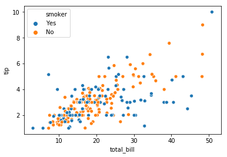

```python
sns.scatterplot(data=tips, x="total_bill",y="tip",hue="smoker")
```

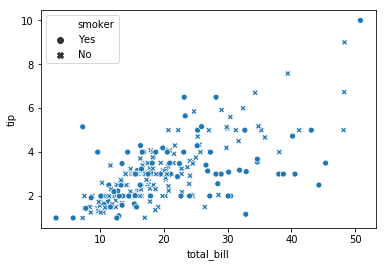

```python
sns.scatterplot(data=tips, x="total_bill",y="tip",style="smoker")
```

- 실수형 데이터 또한 함께 표현하고 싶은 경우!  
  `hue`에 numerical 변수 이름을 지정하면 변수 값에 따라 색상이 달라짐  
  `size`에 numerical 변수 이름을 지정하면 변수 값에 따라 크기가 달라짐

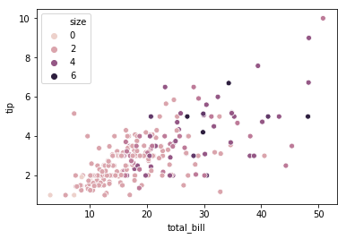

```python
sns.scatterplot(data=tips, x="total_bill",y="tip",hue="size")
```

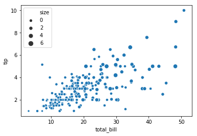

```python
sns.scatterplot(data=tips, x="total_bill",y="tip",size="size")
```

#### 2.1.2. 두 그래프: 분석하고자 하는 데이터가 categorical 일 때 !

> **사용 방법:**  
> sns.catplot(x축 데이터,y축 데이터,data)

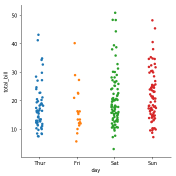

```python
sns.catplot(x="day",y="total_bill",data=tips) #요일에 따른 전체 지불 금액
```

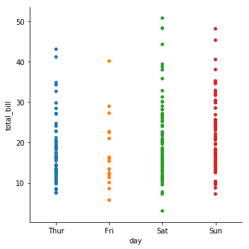

```python
sns.catplot(x="day",y="total_bill",data=tips, jitter=False)
#요일에 따른 전체 지불 금액
# jitter 인자를 False로 설정하여 결과를 일직선으로 나타낼 수 있음
```

#### 여기서 잠깐 ! 비슷한 형태의 plot들을 살펴보고 넘어가자.

- stripplot  
  stripplot은 마치 스캐터 플롯처럼 모든 데이터를 점으로 그려준다.  
  사용 방법:  
  sns.stripplot(`x축 데이터`,`y축 데이터`,`data`)

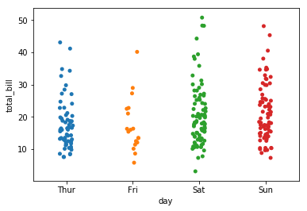

```python
sns.stripplot(x="day", y="total_bill", data=tips)
```

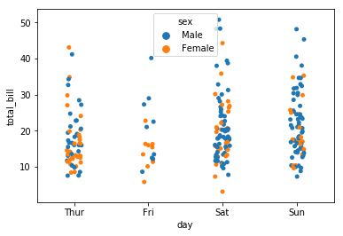

```python
sns.stripplot(x="day", y="total_bill", hue="sex", data=tips, jitter=True) # hue 추가 가능
```

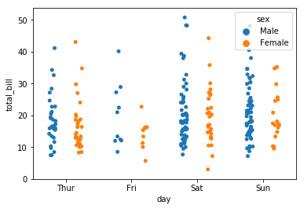

```python
sns.stripplot(x="day", y="total_bill", hue="sex",
              data=tips, jitter=True, dodge=True)
# dodge 옵션 쓰면 남여 따로 볼 수 있음
```

- swamplot  
  swarmplot은 stripplot과 비슷하지만 데이터를 나타내는 점이 겹치지 않도록 옆으로 이동 사용 방법:  
  sns.swarmplot(`x축 데이터`,`y축 데이터`,`data`)

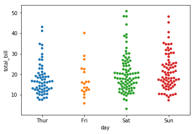

```python
sns.swarmplot(x="day", y="total_bill", data=tips)
```

#### 다시 catplot으로!

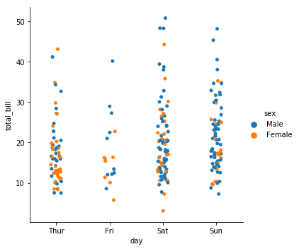

```python
sns.catplot(x="day",y="total_bill", hue='sex',data=tips)
# 역시 hue 파라미터에 categorical 변수 지정 가능
# 성별에 따라 색이 달라짐
```

### 2.2. Box Plot

박스는 실수 값 분포에서 1사분위수(Q1)와 3사분위수(Q3)를 뜻하고, 3사분위수와 1사분수의 차이(Q3 - Q1)는 IQR이라고 한다.  
1사분위 수보다 1.5 x IQR 만큼 낮은 값과 3사분위 수보다 1.5 x IQR 만큼 높은 값의 구간을 기준으로 그 바깥의 점은 outlier(이상치)이다.

> **사용 방법:**  
> sns.catplot(`x축 데이터`, `y축 데이터`, kind=`box`, `data`)

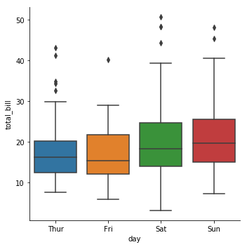

```python
sns.catplot(x="day", y="total_bill", kind="box", data=tips)
```

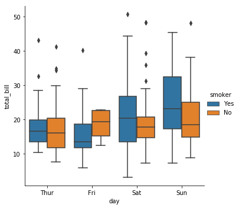

```python
sns.catplot(x="day", y="total_bill", hue="smoker", kind="box", data=tips) #hue 파라미터 추가
```

### 2.3. Violin Plot

`boxplot`은 분포의 간략한 특성만 보여주지만 `violinplot`은 카테고리값에 따른 각 분포의 실제 데이터나 전체 형상을 보여준다는 장점이 있다.  
`violinplot`은 세로 방향으로 커널 밀도 히스토그램을 그려주는데 왼쪽과 오른쪽이 대칭이 되도록 하여 바이올린처럼 보인다고 하여 붙은 이름이다.

> **사용 방법:**  
> sns.violinplot(x축 데이터,y축 데이터,data)

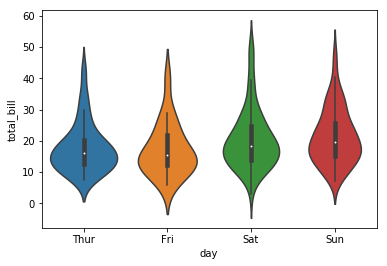

```python
sns.violinplot(x="day", y="total_bill", data=tips)
```

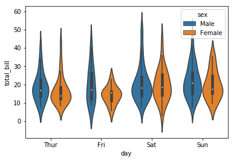

```python
sns.violinplot(x="day", y="total_bill", hue="sex", data=tips) # hue 파라미터 추가 가능
```

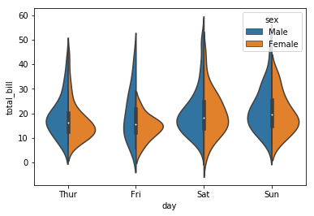

```python
sns.violinplot(x="day", y="total_bill", hue="sex", data=tips, split=True) # split 옵션 추가하면 반은 남자, 반은 여자로!
```

### 2.4. Bar Plot

카테고리 값에 따른 실수 값의 평균과 편차를 표시하는 기본적인 바 차트를 생성

> **사용 방법:**  
> sns.barplot(`x축 데이터`,`y축 데이터`,`data`)

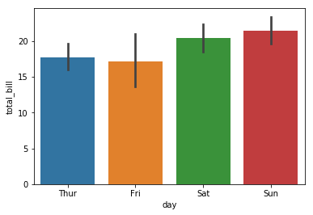

```python
sns.barplot(x="day", y="total_bill", data=tips)
```

#### 타이타닉 데이터에 적용해보기

1. 타이타닉 데이터 확인

```python
titanic.head()
```

|  | survived | pclass | sex | age | sibsp | parch | fare | embarked | class | who | adult_male | deck | embark_town | alive | alone |
| --- | --- | --- | --- | --- | --- | --- | --- | --- | --- | --- | --- | --- | --- | --- | --- |
| 0 | 0 | 3 | male | 22.0 | 1 | 0 | 7.2500 | S | Third | man | True | NaN | Southampton | no | False |
| 1 | 1 | 1 | female | 38.0 | 1 | 0 | 71.2833 | C | First | woman | False | C | Cherbourg | yes | False |
| 2 | 1 | 3 | female | 26.0 | 0 | 0 | 7.9250 | S | Third | woman | False | NaN | Southampton | yes | True |
| 3 | 1 | 1 | female | 35.0 | 1 | 0 | 53.1000 | S | First | woman | False | C | Southampton | yes | False |
| 4 | 0 | 3 | male | 35.0 | 0 | 0 | 8.0500 | S | Third | man | True | NaN | Southampton | no | True |

1. bar plot 그리기 (catplot을 이용해서 그려보자!)

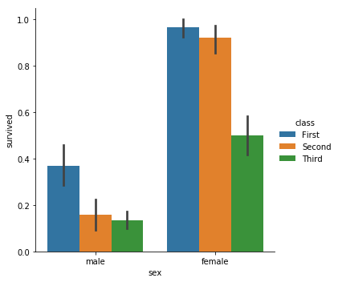

```python
sns.catplot(x="sex", y="survived", hue="class", kind="bar", data=titanic) #catplot에 kind="bar"를 이용
```

### 2.5. Rug Plot

러그(rug) 플롯은 데이터 위치를 x축 위에 작은 선분(rug)으로 나타내어 실제 데이터들의 위치를 보여줌

> **사용 방법:**  
> sns.rugplot(`data`)

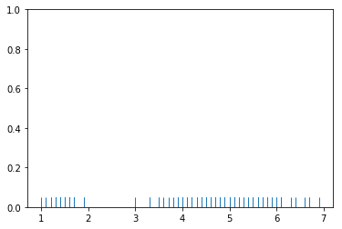

```python
sns.rugplot(iris.petal_length.values)
```

```python
iris.petal_length.values
```

```
array([1.4, 1.4, 1.3, 1.5, 1.4, 1.7, 1.4, 1.5, 1.4, 1.5, 1.5, 1.6, 1.4,
       1.1, 1.2, 1.5, 1.3, 1.4, 1.7, 1.5, 1.7, 1.5, 1. , 1.7, 1.9, 1.6,
       1.6, 1.5, 1.4, 1.6, 1.6, 1.5, 1.5, 1.4, 1.5, 1.2, 1.3, 1.4, 1.3,
       1.5, 1.3, 1.3, 1.3, 1.6, 1.9, 1.4, 1.6, 1.4, 1.5, 1.4, 4.7, 4.5,
       4.9, 4. , 4.6, 4.5, 4.7, 3.3, 4.6, 3.9, 3.5, 4.2, 4. , 4.7, 3.6,
       4.4, 4.5, 4.1, 4.5, 3.9, 4.8, 4. , 4.9, 4.7, 4.3, 4.4, 4.8, 5. ,
       4.5, 3.5, 3.8, 3.7, 3.9, 5.1, 4.5, 4.5, 4.7, 4.4, 4.1, 4. , 4.4,
       4.6, 4. , 3.3, 4.2, 4.2, 4.2, 4.3, 3. , 4.1, 6. , 5.1, 5.9, 5.6,
       5.8, 6.6, 4.5, 6.3, 5.8, 6.1, 5.1, 5.3, 5.5, 5. , 5.1, 5.3, 5.5,
       6.7, 6.9, 5. , 5.7, 4.9, 6.7, 4.9, 5.7, 6. , 4.8, 4.9, 5.6, 5.8,
       6.1, 6.4, 5.6, 5.1, 5.6, 6.1, 5.6, 5.5, 4.8, 5.4, 5.6, 5.1, 5.1,
       5.9, 5.7, 5.2, 5. , 5.2, 5.4, 5.1])
```

### 2.6. KDe Plot

히스토그램보다 부드러운 형태의 분포 곡선을 보여주는 방법

> **사용 방법:**  
> sns.kdeplot(`data`)

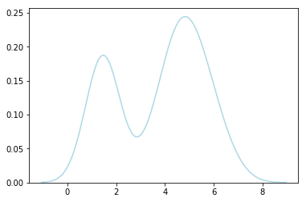

```python
sns.kdeplot(iris.petal_length.values, color="lightblue")
```

- dist plot  
  러그 + 커널 밀도 + 히스토그램 표시 기능  
  사용 방법 :  
  sns.`distplot`(`data`, `kde`=True or False, `rug`=True or False)

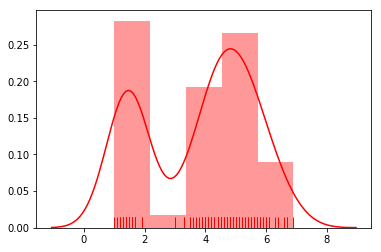

```python
sns.distplot(iris.petal_length.values, kde=True, rug=True, color="red")
```

### 2.7. Count Plot

각 카테고리 값별로 데이터가 얼마나 있는지 표시 가능 (빈도 수를 그래프에 표시)

> **사용 방법:**  
> sns.countplot(x=column_name, data)

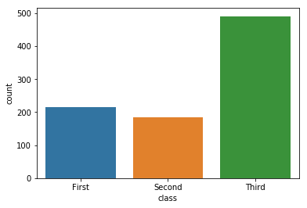

```python
sns.countplot(x="class", data=titanic)
```

class별 승객 수를 나타낼 수 있다.

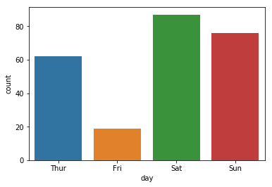

```python
sns.countplot(x="day", data=tips)
```

요일별 팁을 준 횟수를 알 수 있다.

### 2.8. Joint Plot

스캐터 플롯뿐 아니라 차트의 가장자리(margin)에 각 변수의 히스토그램도 그린다.

> **사용 방법:**  
> sns.jointplot(x, y, data, kind)

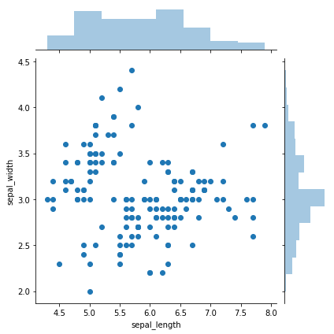

```python
sns.jointplot(x="sepal_length",y="sepal_width",data=iris) #kind = 'scatter' 일 때
```

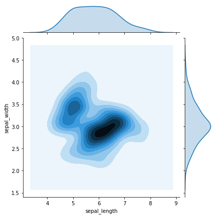

```python
sns.jointplot(x="sepal_length", y="sepal_width", data=iris, kind="kde") #kind = 'kde' 일 때
```

### 2.9. Pair Plot

3차원 이상의 데이터라면 seaborn 패키지의 pairplot 명령을 사용하자.  
pairplot은 데이터프레임을 인수로 받아 그리드 형태로 각 데이터 열의 조합에 대해 스캐터 플롯을 그려준다.  
같은 데이터가 만나는 대각선 영역에는 해당 데이터의 히스토그램을 생성한다.

> **사용 방법:**  
> sns.sns.pairplot(`data`)

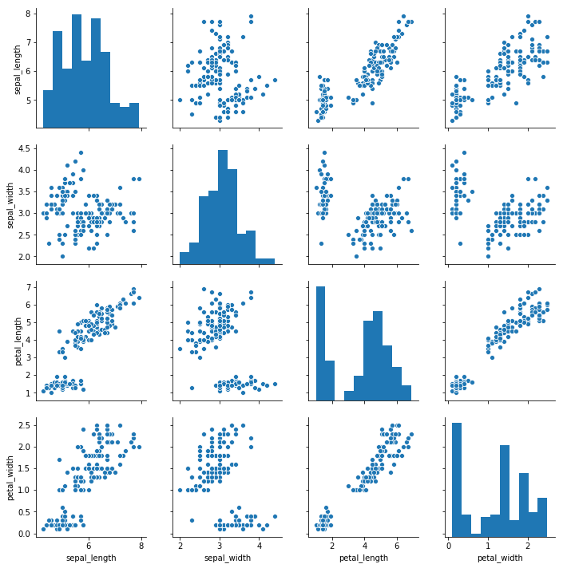

```python
sns.pairplot(iris)
```

#### Species에 따른 구분이 안 되어 있네? 어떻게 하면 구분할 수 있을까?

**hue 파라미터** 이용하면 됨!  
seaborn은 matplotlib의 확장 패키지이기 때문에 marker의 종류가 같음

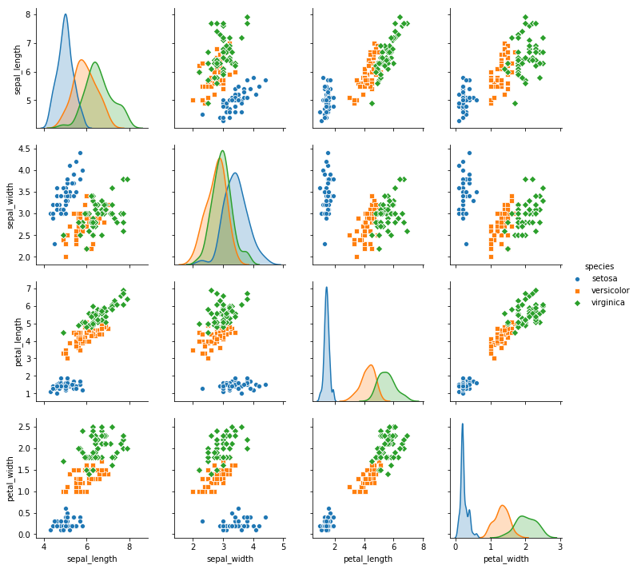

```python
sns.pairplot(iris, hue="species", markers=["o", "s", "D"])
```

### 2.10. Reg Plot & LM Plot

변수들 간의 선형 관계를 확인할 때에 사용한다.

> **사용 방법:**
> 1. sns.regplot(`x축 데이터`,`y축 데이터`,`data`)
> 2. sns.lmplot(`x축 데이터`,`y축 데이터`,`data`)

실제로 regplot보다 lmplot이 더 많이 쓰이는데 그 이유는 lmplot에서만 hue 파라미터가 적용되기 때문!

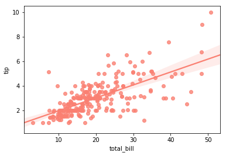

```python
sns.regplot(x="total_bill", y="tip", data=tips, color="salmon")
```

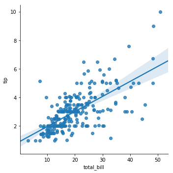

```python
sns.lmplot(x="total_bill", y="tip", data=tips)
```

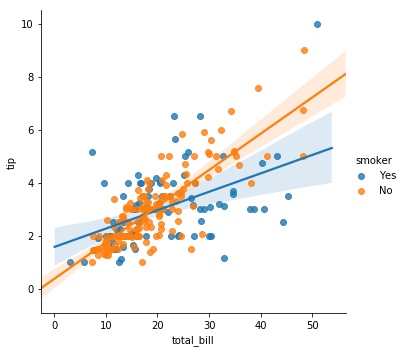

```python
sns.lmplot(x="total_bill", y="tip", hue="smoker", data=tips) #smoker에 따라 색상 지정 가능
```